rm(list = ls())

setwd("C:/Users/USER/Downloads") # set directory

set.seed(33839)

###### Fit GPD to DHSI

library("evir")

# if the package evir has not been installed, install it by running install.packages("evir")

source("gpd_code.R")# package functions in Rsafd, need to save gpd_code.R in the same folder as this file

# this function uses the package robustbase. If the package has not been installed, install it by running install.packages("robustbase")

# Q1(1)

HSI <- read.table("DHSI.csv",header = T, sep=",")

attach(HSI)

DHSI<-(HSI$Close)

n<-length(DHSI)

DHSIRET <- diff(DHSI)/DHSI[1:(n-1)] #compute raw returns

is.vector(DHSIRET)

## [1] TRUE

c(mean(DHSIRET),sd(DHSIRET))

## [1] 0.0003481433 0.0161844977

# Q1(2)

SHAPE.XI <- TRUE

eda.shape(DHSIRET)

## DHSIRET

[figure not shown]

# From the top left graph and the bottom left graph,

# we can know about the shape of the distribution,

# which is a bell shape but is very tall, so it is not a normal distributin.

# Also, most of the data are around the centre which is 0.

# Also, it has small dispersion/variance in general.

# From the top right graph, we can know that it ranges

# from around -0.35 to 0.2. The median is 0.

# The interquartile range is ranged from some value slightly

# below 0 to some value slightly above 0.

# There are just a few outliers, which can be ignored.

# Most data are ranged between -0.1 and 0.1.

# From the bottom right graph, we can see that there is an

# upwards sloping curve above the reference line on the

# right tail so we determine that the sample distribution has

# a heavier right tail than the that of the normal distribution.

# Similarly, by symmetry, we can know that the left tail of the

# sample distribution is heavier than that of the normal

# distribution as well.

# This also means that the sample distribution does not follow a normal distriburion.

# Q1(3)

par(mfrow=c(1,2))

shape.plot(DHSIRET,tail="upper")

shape.plot(DHSIRET,tail="lower")

[figure not shown]

# Specification of the tails:

# First, We don’t want the tail to contain too many observations in the center

# as we want to get the untypical observation, instead of the typical ones

# Second, We want the tail to contain “enough” observations to ensure quality of the fitting

# Therefore, we don't want the tail to contain just the top 3 % or the bottom 3%

# Third, We don’t want the specification of “tail” to affect the fitting too much

# That's we don't the choice of the threshold to affect the value of the estimation of Xi,

# which means that the estimation of xi within the neighborhood of that choice of Xi should be similar

# So, considering for the above 3 rules, we will just consider the middle part of the graph, which is not near 0 or 0.03,

# and find a region of threshold where their estimates of Xi together show in general a flat line.

# Therefore, for the right tail, I will take 0.0215 as the threshold as it is in the middle part of

# the graph and the estimates of Xi of it and its small neighborhood are similar.

# Then for the left tail, I will take -0.0245 as the threshold as the it is in the middle part of

# the graph and the estimates of Xi of it and its small neighborhood are similar.

# fit

DHSIRET.est <- gpd.tail(DHSIRET, upper=0.0215,lower=-0.0245)

[figure not shown]

# As the points of the 2 graphs are essentially on a straight line,

# the GPD should be an appropriate model to fit the tails as the distribution of

# the fitted GDP distribution of the 2 tails is respectively quite the same as

# the real right tail distribution and the real left tail distribution.

# xi

DHSIRET.est[[1]]$par.ests[1] # upper

## xi

## 0.2366114

DHSIRET.est[[2]]$par.ests[1] # lower

## xi

## 0.2819297

# (Another) checking the goodness of model fitting

par(mfrow=c(1,2))

tailplot(DHSIRET.est[[1]]) # upper tail

title("Plot of upper tail in log - log scale")

tailplot(DHSIRET.est[[2]]) # lower tail

title("Plot of lower tail in log - log scale")

[figure not shown]

# From the 2 graphs, we can see that overall, fitted distributions match with empirical distribution very well,

# even though both tail estimates miss several extreme values.

# Therefore, for the fitting results, we can say that the GPD fits the 2 tails well

# as the fitted GPD distribution is quite the same as the real tail distributions,

# for both cases of the left and the right.

# Q1(4)

par(mfrow=c(1,1))

SDHSIRET=gpd.2q(runif(10000), DHSIRET.est)

qqplot(DHSIRET,SDHSIRET,main = "Q-Q Plot of DHSIRET vs S_DHSIRET")

abline(a=0,b=1)

[figure not shown]

# As points are mostly on the diagonal. The fitting result is very close to the empirical

# data. Therefore, we can say that the GPD fits the 2 tails well

# as the fitted GPD distribution is quite the same as the real tail distributions,

# for both cases of the left and the right.

# Q1(5)

q<-0.005

VaR_emp <- - quantile(DHSIRET,q) # using empirical quantile

VaR_Normal <- - qnorm(q,mean(DHSIRET),sd(DHSIRET)) # assuming that the daily raw return is normally distributed

VaR_GPD <- - quantile(SDHSIRET,q) # using the Monte Carlo sample S_DHSIRET that you generated from the fitted GPD model

VaR_Ratio_N_GPD <- (VaR_Normal - VaR_GPD)/VaR_GPD

VaR_Ratio_N_emp = (VaR_Normal - VaR_emp)/VaR_emp

VaR_Ratio_GPD_emp = (VaR_GPD - VaR_emp)/VaR_emp

round(c(VaR_emp,VaR_Normal,VaR_GPD,VaR_Ratio_N_GPD, VaR_Ratio_N_emp, VaR_Ratio_GPD_emp),3)

## 0.5% 0.5% 0.5% 0.5% 0.5%

## 0.052 0.041 0.053 -0.218 -0.210 0.010

# Differences: VaR under normal assumption is smaller than the VaR under GPD assumption by about 22%.

# As the 2 distributions, the normal model and the well-fitted model, do not match.

# This difference will be huge when the portfolio is large.

# Also, it means that the normal model underestimates the loss, which is under GPD assumption.

# In addition, VaR under normal assumption is smaller than the empirical VaR by about 21%

# as the empirical distribution does not match with the normal distribution well. The normal model is underfitting the real data.

# This difference will be huge when the portfolio is large.

# Also, it means that the normal model underestimates the real/empirical loss.

# Similarities: Empirical VaR ≈ VaR under the GPD assumptions as the difference between these two is close to 0

# because from the above-mentioned, in overall, fitted distributions match with empirical distribution very well.

# Q1(6)

### empirical ES

ES_emp <- mean(- DHSIRET[- DHSIRET > VaR_emp]) # using empirical conditional mean

## under normal assumption

mu_DHSIRET <- mean(DHSIRET)

sd_DHSIRET <- sd(DHSIRET)

N<-100000

X<-rnorm(N,mu_DHSIRET,sd_DHSIRET)

ES_N <- mean( - X[- X > VaR_Normal]) # the ES assuming that the daily raw return is normally distributed

ES_GPD <- mean(- SDHSIRET[- SDHSIRET > VaR_GPD]) # based on the fitted GPD distribution

round(c(ES_emp, ES_N, ES_GPD),3)

## [1] 0.081 0.047 0.084

# Differences: the ES under normal assumption is smaller than the empirical ES

# because the normal model is underfitting the real data. The normal model and empirical distribution don't match

# The normal model underestimes the ES.

# In additon, the ES under normal assumption is smaller than the ES under GPD assumption as well

# because the 2 distribution, the normal distribution and the GPD model, don't match

# and the normal model underestimates the ES, which is under fitted GPD assumption

# Similarities: The ES under the GPD assumption is quite close to the empirical ES

# because from the above-mentioned, in overall, fitted distributions match with empirical distribution very well.

# 2(1)

UTILITIES<-read.csv("UTILITIES.csv")

X <- UTILITIES[ , 1 ]

Y <- UTILITIES[ , 2 ]

summary(X)

## Min. 1st Qu. Median Mean 3rd Qu. Max.

## -0.1284964 -0.0132567 0.0003758 0.0023640 0.0180709 0.1191371

summary(Y)

## Min. 1st Qu. Median Mean 3rd Qu. Max.

## -0.2460761 -0.0163314 0.0000000 0.0005119 0.0179138 0.1494248

mu <- c(mean(X), mean(Y)) # the means of X and Y

mu

## [1] 0.0023640532 0.0005119416

sd_X = sd(X) # the standard deviation of X

sd_Y = sd(Y) # the standard deviation of Y

sd_X

## [1] 0.0270494

sd_Y

## [1] 0.0363912

rho_XY = cor(X,Y)

rho_XY

## [1] 0.5446365

# 2(2)

# the 2-percentiles of the variable X + Y under jointly Gaussian distribution

qnorm(0.02, mean = mean(X)+mean(Y), sd = sqrt(var(X)+var(Y)+2*cov(X,Y)))

## [1] -0.1119913

# the 2-percentiles of the variables X - Y under jointly Gaussian distribution

qnorm(0.02, mean = mean(X)-mean(Y), sd = sqrt(var(X)+var(Y)+2*(1)*(-1)*cov(X,Y)))

## [1] -0.06256338

# the empirical estimate of of 2-percentiles of the variable X + Y

quantile(X+Y, 0.02)

## 2%

## -0.1014621

# the empirical estimate of of 2-percentiles of the variable X - Y

quantile(X-Y, 0.02)

## 2%

## -0.05818855

# Q3(1)

n = 1024

X = rnorm(n)

Y = X^2

par(mfrow=c(1,1))

plot(X,Y)

[figure not shown]

cor(X,Y) # the sample correlation̂ρ(X, Y )

## [1] 0.00619739

# Q3(2)

XX = rnorm(n, 3, 1)

YY = XX^2

par(mfrow=c(1,1))

plot(XX,YY)

[figure not shown]

cor(XX,YY) # the sample correlation ̂ ρ(XX, Y Y )

## [1] 0.9764745

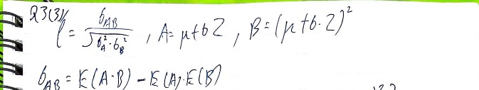

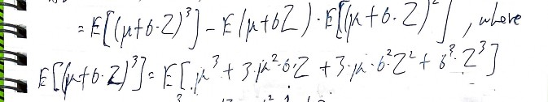

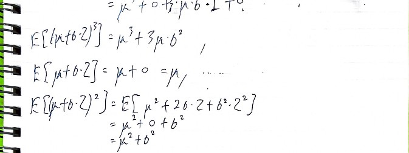

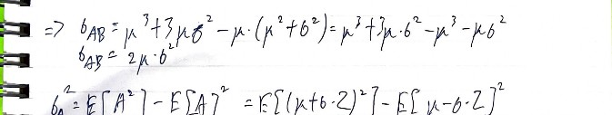

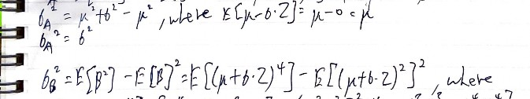

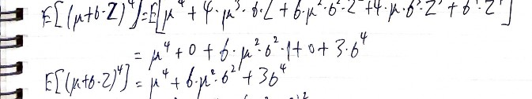

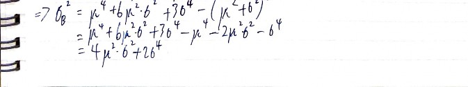

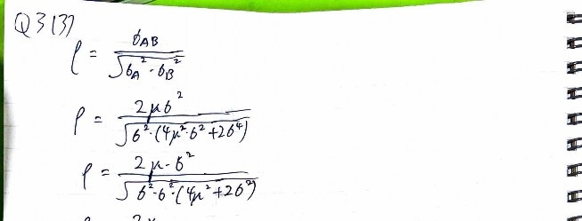

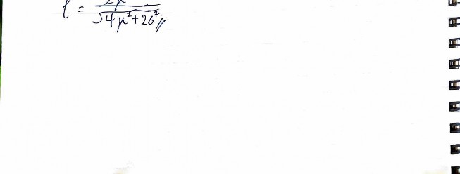

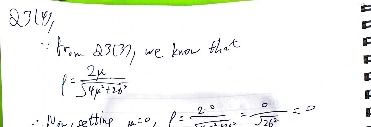

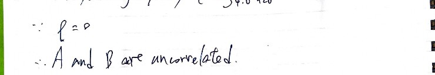

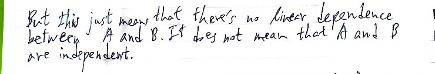

[3 more figures not shown]